# ANLY 512 - Problem Set 2

Anscombe’s quartet

Your Name

2016-09-20

## Rmarkdown

Rmarkdown is run on a package called `knitr()`. `knitr()` is a powerful tool for creating reports and summaries of your quantiative research, and it is an important part of a **reproducible research** toolbox. The `knitr` package was developed by [Yihui Xie](http://yihui.name/knitr/) a statistics Ph.D. who now works at Rstudio. The value of **reproducible research** especially in the process of data exploration and visualization is immense. There are tons of powerful ways you can use the `knitr()` package to increase your efficiency and produce amazing output from your analyses. During this course we will continually build on the capabilities of *rmarkdown*. But for today we are simply going to get comfortable with the primary reproducible research tool for `R` which is the `knitr` package.

Since many of you are using **Rstudio** you will benefit from the tight integration which the Rstudio interface has with the `knitr` package. For instance in the toolbar above the text editor quadrant of the Rstudio interface you will see a “Knit” button. That essentially executes the `knitr::render()` function in the background allowing the user to create reports and package output without having to execute commands in the `R` console. A great resource for more details on the `knitr` package is [knitr in a knutshell](http://kbroman.org/knitr_knutshell/) by [Karl Browman](http://kbroman.org/), or for a longer exposition you could read [Dynamic Documents with R and knitr](https://www.amazon.com/dp/1498716962/ref=cm_sw_su_dp).

## Objectives

The objectives of this problem set is to orient you to a number of activities in `R`. And to conduct a thoughtful exercise in appreciating the importance of data visualization. For each question create a code chunk or text response that completes/answers the activity or question requested. Finally, upon completion name your final output `.html` file as: `YourName_ANLY580_LTSP2016.html` and upload it to the “Problem Set 1”" assignmenet on Moodle.

## Questions

1. Anscombes quartet is a set of 4 $x,y$ data sets that were published by *Francis Anscombe* in a 1973 paper [*Graphs in statistical analysis*](https://www.jstor.org/stable/2682899?seq=1#page_scan_tab_contents). For this first question load the `anscombe` data that is part of the `library(datasets)` in `R`. And assign that data to a new object called `data`.

```r
data <- anscombe
```

2. Summarise the data by calculating the mean, variance, for each column and the correlation between each pair (eg. x1 and y1, x2 and y2, etc) (Hint: use the `fBasics()` package!)

```r
cat("mean of column 1 to 8")
```

```
## mean of column 1 to 8
```

```r
data %>%
    group_by() %>%
    summarise_each(funs(mean)) %>%
    select(mean_ = everything()) %>% kable()
```

| mean_1 | mean_2 | mean_3 | mean_4 | mean_5 | mean_6 | mean_7 | mean_8 |
| --- | --- | --- | --- | --- | --- | --- | --- |
| 9 | 9 | 9 | 9 | 7.500909 | 7.500909 | 7.5 | 7.500909 |

```r
cat("variance of column 1 to 8")
```

```
## variance of column 1 to 8
```

```r
data %>%
    group_by() %>%
    summarise_each(funs(var)) %>%
    select(var_ = everything()) %>% kable()
```

| var_1 | var_2 | var_3 | var_4 | var_5 | var_6 | var_7 | var_8 |
| --- | --- | --- | --- | --- | --- | --- | --- |
| 11 | 11 | 11 | 11 | 4.127269 | 4.127629 | 4.12262 | 4.123249 |

Before calculating the pairwise (aligned on position) correlation, notice that data is clearly not [tidy data](http://vita.had.co.nz/papers/tidy-data.pdf), there is one dimension, factor 1:4, clearly hidden in the column name. Thus, before we do anything further, restructure data to a tidy data set, for easier loop in regression, easier plotting too.

```r
data[,1:4] %>%
    gather("num", "x", 1:4) %>%
    mutate(num = str_sub(num, 2), id = 1:44) %>%
    inner_join(
        data[,5:8] %>%
            gather("num", "y", 1:4) %>%
            mutate(num = str_sub(num, 2), id = 1:44)
    ) %>%
    select(-id) -> data
data %>% head() %>% kable()
```

| num | x | y |
| --- | --- | --- |
| 1 | 10 | 8.04 |
| 1 | 8 | 6.95 |
| 1 | 13 | 7.58 |
| 1 | 9 | 8.81 |
| 1 | 11 | 8.33 |
| 1 | 14 | 9.96 |

Looking good! Now we run pair wise correlation for every `num` with ease.

```r
data %>%
    group_by(num) %>%
    summarise(corr_xy = cor(x,y)) %>% kable()
```

| num | corr_xy |
| --- | --- |
| 1 | 0.8164205 |
| 2 | 0.8162365 |
| 3 | 0.8162867 |
| 4 | 0.8165214 |

Notice they are almost the same.

3. Create scatter plots for each $x, y$ pair of data.

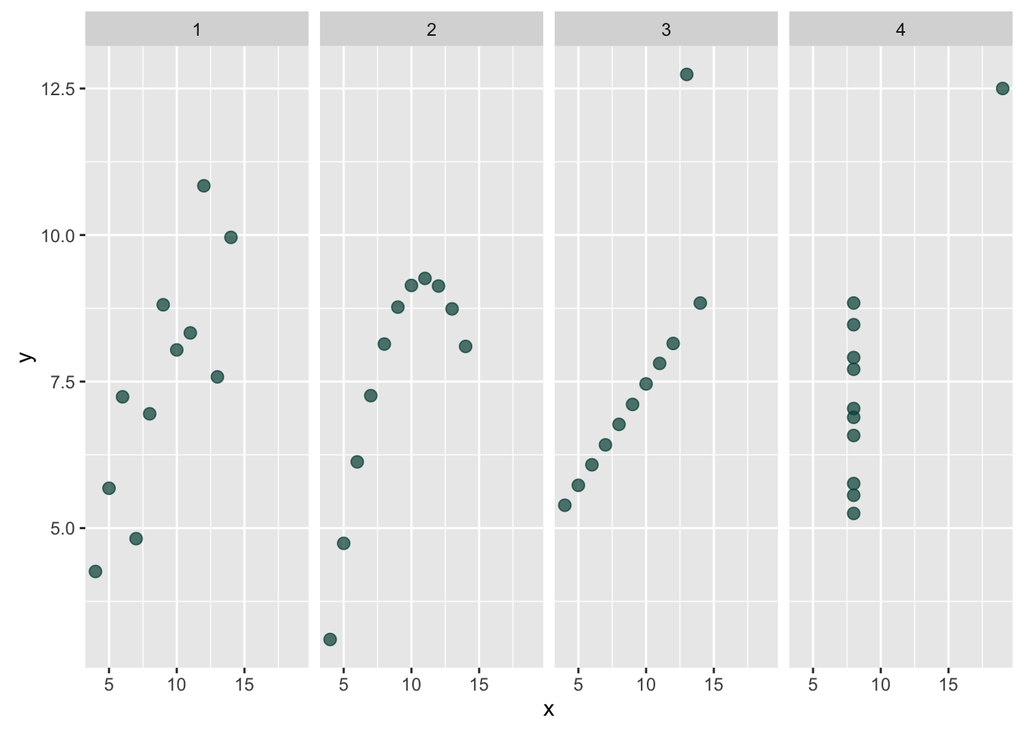

```r
data %>%
    ggplot(aes(x, y)) +
    geom_point(colour = "#004D43", size = 2.5, alpha = 0.7) +
    facet_grid(. ~ num)
```

4. Now change the symbols on the scatter plots to solid circles and plot them together as a 4 panel graphic

This is actually done through last step, already solid dots.

5. Now fit a linear model to each data set using the `lm()` function.
6. Now combine the last two tasks. Create a four panel scatter plot matrix that has both the data points and the regression lines. (hint: the model objects will carry over chunks!)

This two steps could be completed in one ggplot call.

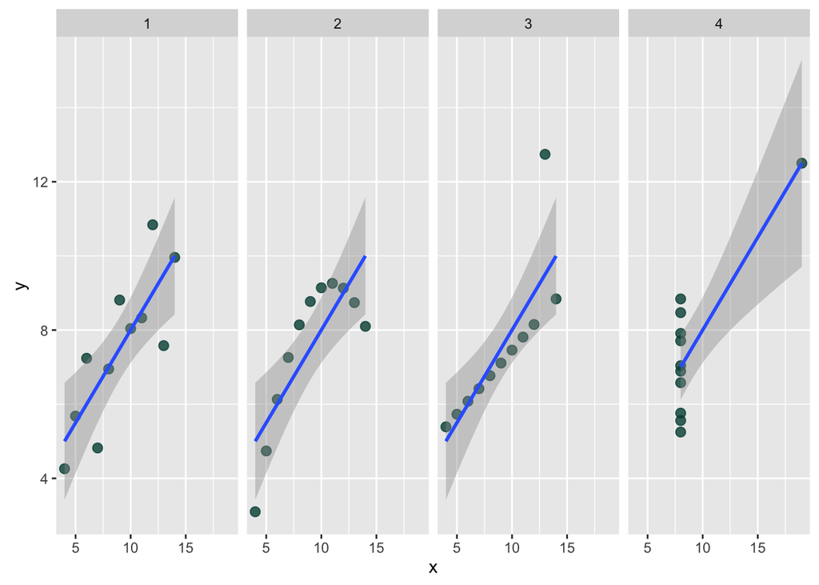

```r
data %>%
    ggplot(aes(x, y)) +
    geom_point(colour = "#004D43", size = 2.5, alpha = 0.8) +
    stat_smooth(method = 'lm', size = 1) +
    facet_grid(. ~ num)
```

7. Now compare the model fits for each model object.

The models are the same

```r
for (i in unique(data$num)) {
    fit = lm(y ~ x, data[data$num == i, ])
    print(fit$coefficients)
}
```

(Intercept) x 3.0000909 0.5000909 (Intercept) x 3.000909 0.500000 (Intercept) x 3.0024545 0.4997273 (Intercept) x 3.0017273 0.4999091

8. In text, summarize the lesson of Anscombe’s Quartet and what it says about the value of data visualization.

Anscombe data set demonstrate that data viz can reveal the relationship in the data that’s not visible. This is a good example of Tufte’s concept of [Graphiccal Excellence](http://sphweb.bumc.bu.edu/otlt/MPH-Modules/BS/DataPresentation/DataPresentation3.html).